# Exploring IPython Magic Functions

To get this notebook running under windows, execute

```
jupyter notebook
```

on the command line. (Yes, I know you have to already have jupyter running to see this.)

## Explore basic information

%magic and %quickref display longish pages of very good information!

```python
%magic
```

```python
%quickref
```

```python
#list available line & cell magics
% lsmagic
```

```python
#list aliases
%alias
```

## Profile, Configuration, & Packages

- %unload_ext / %load_ext Unload/Load an IPython extension by its module name.
- %reload_ext

```python
#exposes most of the IPython config system.
%config

# what could I do with DisplayFormatter?
%config DisplayFormatter
```

```
Available objects for config:
     ZMQInteractiveShell
     HistoryManager
     PrefilterManager
     IPCompleter
     PromptManager
     DisplayFormatter
     MagicsManager
     ScriptMagics
     AliasManager
     IPKernelApp
     StoreMagics
     StoreMagics
DisplayFormatter options
----------------------
DisplayFormatter.active_types=<List>
    Current: [u'text/plain', u'image/jpeg', u'text/html', u'image/svg+xml', u'image/png', u'application/javascript', u'text/markdown', u'text/latex', u'application/json', u'application/pdf']
    List of currently active mime-types to display. You can use this to set a
    white-list for formats to display.
    Most users will not need to change this value.
DisplayFormatter.plain_text_only=<Bool>
    Current: False
```

```python
# my profile
%profile  #is out of date
get_ipython().profile
```

```
default
```

```
WARNING: %profile is now deprecated. Please use get_ipython().profile instead.
```

```
u'default'
```

```python
%env
#interesting that I cannot access the path variable in a later example. It must be a windows thing.
```

[output not shown]

[output cut: 14 more lines]

[output not shown]

## Debugging & Logging

- %pdb: python debugger: toggle on/off
- %qtconsole: Open a qtconsole connected to this kernel. (something for debugging)
- %tb: Print the last traceback with the currently active exception mode.
- %%prun: Run a statement through the python code profiler.

```python
# Logging
# %logstart
# %logstop
%logstate
```

```
Logging has not been activated.
```

# call signature, documentation, & finding stuff

- %pdb: Control the automatic calling of the pdb interactive debugger.
- %pdef: Print the call signature for any callable object.
- %pdoc: Print the docstring for an object.
- %psearch: Search for object in namespaces by wildcard.
- %pinfo: Provide detailed information about an object. '%pinfo object' is just a synonym for object? or ?object.
- %pinfo2: Provide extra detailed information about an object.

## Other Interesting stuff

- %rehashx: Update the alias table with all executable files in $PATH
- %reset: reset namespace
- %who_ls: Return a sorted list of all interactive variables.
- %store: Lightweight persistence for python variables

```python
x='nothing in particular'
%who_ls
# who_ls doesn't list anything when merged with the cell below. I.e., with %store after it.
```

```
['x']
```

```python
%store x
%store
```

```
Stored 'x' (str)
Stored variables and their in-db values:
x             -> 'nothing in particular'
```

## Generate some data

Good examples: https://dzone.com/articles/python-create-fake-data-faker

Faker documentation: http://faker.readthedocs.io/en/master/

```python
#%sc did not work, which is a synonym for !, nor did I see a way to use %install_ext
!pip install fake-factory
```

```python
from faker import Faker
fake = Faker()
fake.name()
```

```
u'Kelly Johns'
```

```python
%pdef Faker
#pdef fake  #Object is not callable.
%pdef fake.name
%pinfo fake.name
```

```
 Faker(locale=None, providers=None, generator=None, includes=None, **config)
  fake.name()
```

```python
import random
listA = random.sample(range(1, 100), 25)
listB = random.sample(range(1, 100), 25)
listOfMonths = [random.randrange(1,12,1) for _ in range (25)]
#display(listA,listOfMonths)
listOfMonths.sort()
#print "sorted list ",listOfMonths
```

## Visualization

- %%svg: Render the cell as an SVG literal. Scalable Vector Graphics (SVG) is an XML-based vector image format for two-dimensional graphics with support for interactivity and animation.
- %pylab: is apparently not recommended/deprecated https://github.com/ipython/ipython/issues/5071/

  ```
        %pylab makes the following imports::

        import numpy
        import matplotlib
        from matplotlib import pylab, mlab, pyplot
        np = numpy
        plt = pyplot

        from IPython.display import display
        from IPython.core.pylabtools import figsize, getfigs

        from pylab import *
        from numpy import *
  ```

  Turns out that this is not recommended, but not quite deprecated. The warning below is supposed to tell me that. NOT!WARNING:

  ```
  pylab import has clobbered these variables: ['random']
  `%matplotlib` prevents importing * from pylab and numpy
  ```

```python
# one-stop setup for visualization
#%pylab

# Turns out that this is not recommended, but not quite deprecated. The warning below is supposed to tell me that. NOT!
```

```python
month_map = {
  'Jan': 1, 'Feb': 2, 'Mar':3, 'Apr':4, 'May':5, 'Jun':6, 'Jul':7,
  'Aug':8,  'Sep': 9, 'Oct':10, 'Nov': 11, 'Dec': 12
}
from IPython.display import display
display(month_map)
```

```
{'Apr': 4,
 'Aug': 8,
 'Dec': 12,
 'Feb': 2,
 'Jan': 1,
 'Jul': 7,
 'Jun': 6,
 'Mar': 3,
 'May': 5,
 'Nov': 11,
 'Oct': 10,
 'Sep': 9}
```

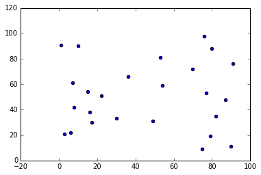

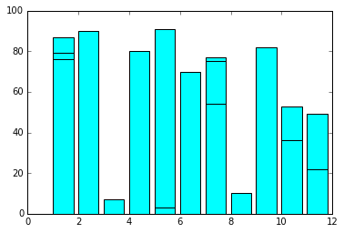

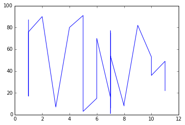

```python
%matplotlib inline

import matplotlib.pyplot as plt
#plt.plot(listOfMonths,listA)
plt.scatter(listA,listB)
plt.show()
plt.bar(listOfMonths,listA,color='cyan')
plt.show()

plt.plot(listOfMonths,listA)
#plt.plot(listOfMonths,listB)
plt.show()
#%pdoc plt.bar
```

```python
%%svg
<!--
## note that html is ignored
-->
<html>
<body>

<h1>My first SVG</h1>

<svg width="100" height="100">
  <circle cx="50" cy="50" r="40" stroke="green" stroke-width="4" fill="yellow" />
</svg>

</body>
</html>
```

```python
%%svg
<!--
# searched briefly for a way to make this modifyable without avail.
# cx1 = "240"
-->

<svg height="150" width="500">
  <ellipse cx="240" cy="100" rx="220" ry="30" style="fill:purple" />
  <ellipse cx="220" cy="70" rx="190" ry="20" style="fill:lime" />
  <ellipse cx="210" cy="45" rx="170" ry="15" style="fill:yellow" />
</svg>
```

## Explore a few use cases

```python
%alias bracket echo "Input in brackets: <%l>"
%bracket howdy
```

```
"Input in brackets: <howdy>"
```

```python
%colors LightBG
# nocolor
# Appears to have no effect, even at the console
```

```python
%%HTML
# HTML 5 template from online somewhere - isn't necessary

<!doctype html>

<html lang="en">
<head>
  <meta charset="utf-8">

  <title>The HTML5 Herald</title>
  <meta name="description" content="The HTML5 Herald">
  <meta name="author" content="SitePoint">

  <link rel="stylesheet" href="css/styles.css?v=1.0">

  <!--[if lt IE 9]>
    <script src="http://html5shiv.googlecode.com/svn/trunk/html5.js"></script>
  <![endif]-->
</head>

<body>
  <script src="js/scripts.js"></script>

    <h1> smart cows moo longer </h1>

</body>
</html>
```

# HTML 5 template from online somewhere - isn't necessary

smart cows moo longer

```python
%%HTML
# HTML snippit is ok
    <h1> smart cows moo longer </h1>
```

# HTML snippit is ok

smart cows moo longer

```python
# Not working as in %magic documentation, likely because am on top of windows,
# running from github/power shell where neither $PATH nor %PATH% are defined.

%alias show echo
PATH='A Python string'
%show $PATH
%show $$PATH
#print $PATH
#print $$PATH
```

```
A Python string
A Python string
```

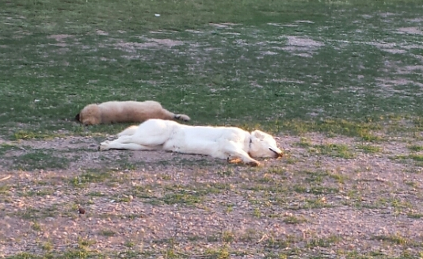

```python
from IPython.display import Image
#Apparently this only works with png, or at least not jpg, and path syntax must follow UNIX convention.
#display(Image(filename="C:\Users\COwnby\Pictures\ByYear\2016\2016-06\20160624_200744.png"))
display(Image(filename="/Users/COwnby/Pictures/ByYear/2016/2016-06/20160624_200744.png"))
```